# Final Project - Kata Horvath

(The following analysis was made on a fragment of a real dataset.)

ABSTRACT

*The effect of theta band stimulation on implicit probabilistic sequence learning*

The aim of the examined study was to compare implicit probabilistic sequence learning performance under theta band transcranial alternating stimulation (tACS) and sham stimulation (only 30 seconds of stimulation for placebo effects, compared to the ~20 min real stimulation condition) over the prefrontal cortex. Preveious research showed that stronger connectivity in theta band during implicit probabilistic sequence learning is associated with poorer learning performance. 13 university students participated in the experiment, all of them completed both sessions, 1 weak apart form each other. ILearning was measured by the Alternating Serial Reaction Time (ASRT) task. This is a four-choice reaction time task, where stimuli follow a hidden sequence, with four repeating elements embedded into four random elements (e.g. 1r2r3r4r). This alternating pattern results in high frequency and low frequency events, and learning is defined by better performence on the former ones and poorer performence on the letter one. An other variable to measure learning is predictive or anticipatory errors. Based on the literature, I hypothesized that participants show weaker learning performance under the theta band tACS which results in smaller learning scores and less predictive errors. However, I suggest that learning-independent, average performance is not affected by the stimulation. Results did not confirm any of the hypothesises meaning that here I could not evince that theta tACS has any effect on implicit probabilistic sequence learning performance.

required packages: “tidyverse” , “dplyr” , “stats” , “wesanderson”

a trial is a *predicitve (or anticipatory) error*, if the uncorrect response equals to the very next stimulus, which is highly frequent based on the sequence. not a predictive error: the subject pressed any other button than the correct or the coming stimulus, responded too slowly or the next stimulus is a low frequency trial. this case is not a real anticipation (you can’t learn random events) marking of predictive errors were made in excel, can be checked based on the retained original values.

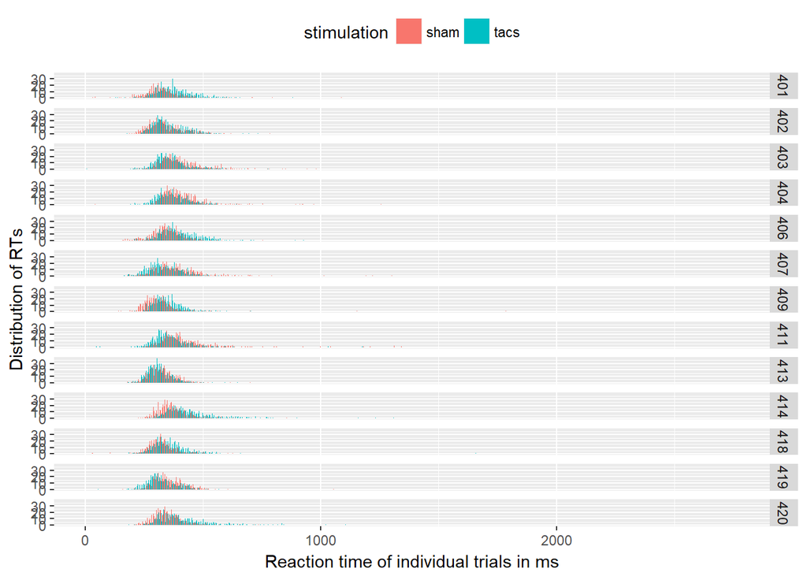

```r
correct_rt_by_trial <- data_stim_raw %>%
  filter(first_acc == 1)
ggplot(correct_rt_by_trial) + geom_histogram(aes(x = first_rt, fill = stimulation), binwidth = 2, position = "dodge")+
  labs(x = "Reaction time of individual trials in ms", y = "Distribution of RTs")+
  theme(legend.position = "top")+
  facet_grid(ID~.)
```

the plot shows that RT distribution is similar in the two experimental conditions. and ressembles the standard ex-gaussian distribution of RTs in all subjects. outlier trials are not excluded, however median instead of mean is calculated to correct these outlier trials.

EXPLORATORY PART:

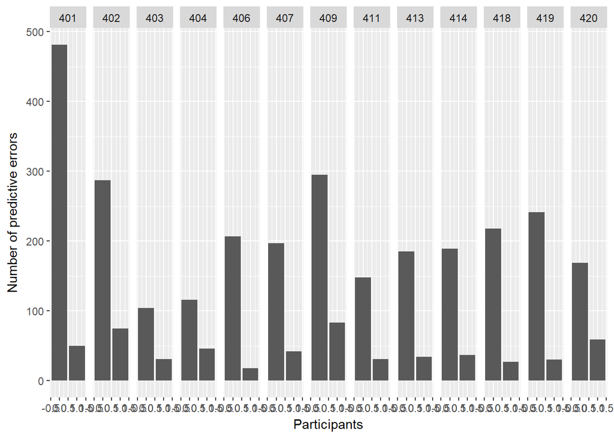

everybody made some predictive errors and that’s something!

calculating means by individuals & stimulation type

```r
means_rt_high <- data_stim_raw %>%
  group_by(ID, stimulation) %>%
  filter(first_acc == 1) %>%
  filter(triplet_type == "H") %>%
  summarise(median_rt = median(first_rt)) %>%
  spread(stimulation, median_rt, fill = NA, convert = FALSE, drop = TRUE, sep = NULL) %>%
  rename(tacs_rt_h = tacs) %>%
  rename(sham_rt_h = sham)
means_rt_low <- data_stim_raw %>%
  group_by(ID, stimulation) %>%
  filter(first_acc == 1) %>%
  filter(triplet_type == "L") %>%
  summarise(median_rt = median(first_rt)) %>%
  spread(stimulation, median_rt, fill = NA, convert = FALSE, drop = TRUE, sep = NULL) %>%
  rename(tacs_rt_l = tacs) %>%
  rename(sham_rt_l = sham)
means_acc_high <- data_stim_raw %>%
  group_by(ID, stimulation) %>%
  filter(triplet_type == "H") %>%
  summarise(avg_acc = mean(first_acc)) %>%
  spread(stimulation, avg_acc, fill = NA, convert = FALSE, drop = TRUE, sep = NULL) %>%
  rename(tacs_acc_h = tacs) %>%
  rename(sham_acc_h = sham)
means_acc_low <- data_stim_raw %>%
  group_by(ID, stimulation) %>%
  filter(triplet_type == "L") %>%
  summarise(avg_acc = mean(first_acc)) %>%
  spread(stimulation, avg_acc, fill = NA, convert = FALSE, drop = TRUE, sep = NULL) %>%
  rename(tacs_acc_l = tacs) %>%
  rename(sham_acc_l = sham)
means_pred_error <- data_stim_raw %>%
  group_by(ID, stimulation) %>%
  filter(first_acc == 0) %>%
  summarise(avg_pred_e = mean(pred_error)) %>%
  spread(stimulation, avg_pred_e, fill = NA, convert = FALSE, drop = TRUE, sep = NULL) %>%
  rename(tacs_pred_e = tacs) %>%
  rename(sham_pred_e = sham)
means_avg_rt <- data_stim_raw %>%
  group_by(ID, stimulation) %>%
  filter(first_acc == 1) %>%
  summarise(avg_rt = mean(first_rt)) %>%
  spread(stimulation, avg_rt, fill = NA, convert = FALSE, drop = TRUE, sep = NULL) %>%
  rename(tacs_avg_rt = tacs) %>%
  rename(sham_avg_rt = sham)
means_avg_acc <- data_stim_raw %>%
  group_by(ID, stimulation) %>%
  summarise(avg_acc = mean(first_rt)) %>%
  spread(stimulation, avg_acc, fill = NA, convert = FALSE, drop = TRUE, sep = NULL) %>%
  rename(tacs_avg_acc = tacs) %>%
  rename(sham_avg_acc = sham)
```

put these together

```r
for_analysis <- bind_cols(means_acc_low, means_acc_high, means_rt_low,
                          means_rt_high, means_pred_error, means_avg_acc, means_avg_rt) %>%
  mutate(ID1 = NULL, ID2 = NULL, ID3 = NULL, ID4 = NULL, ID5 = NULL, ID6 = NULL) %>%
  mutate(tacs_rt_ls = tacs_rt_l - tacs_rt_h) %>%
  mutate(sham_rt_ls = sham_rt_l - sham_rt_h) %>%
  mutate(tacs_acc_ls = tacs_acc_h - tacs_acc_l) %>%
  mutate(sham_acc_ls = sham_acc_h - sham_acc_l)

rm(means_acc_high, means_acc_low, means_avg_acc, means_avg_rt, means_pred_error,
   means_rt_high, means_rt_low, correct_rt_by_trial, pred_error_num)
```

STATISTICAL ANALYIS

first, PLOTS: check outliers

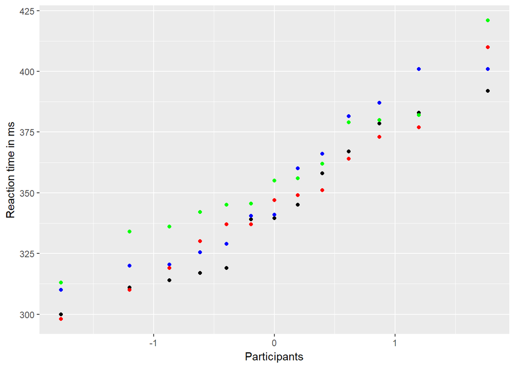

```r
ggplot(for_analysis)+
  geom_qq(mapping = aes(sample = sham_rt_h), color = "black")+
  geom_qq(mapping = aes(sample = sham_rt_l), color = "blue")+
  geom_qq(mapping = aes(sample = tacs_rt_h), color = "red")+
  geom_qq(mapping = aes(sample = tacs_rt_l), color = "green")+
  labs(y = "Reaction time in ms" , x = "Participants")
```

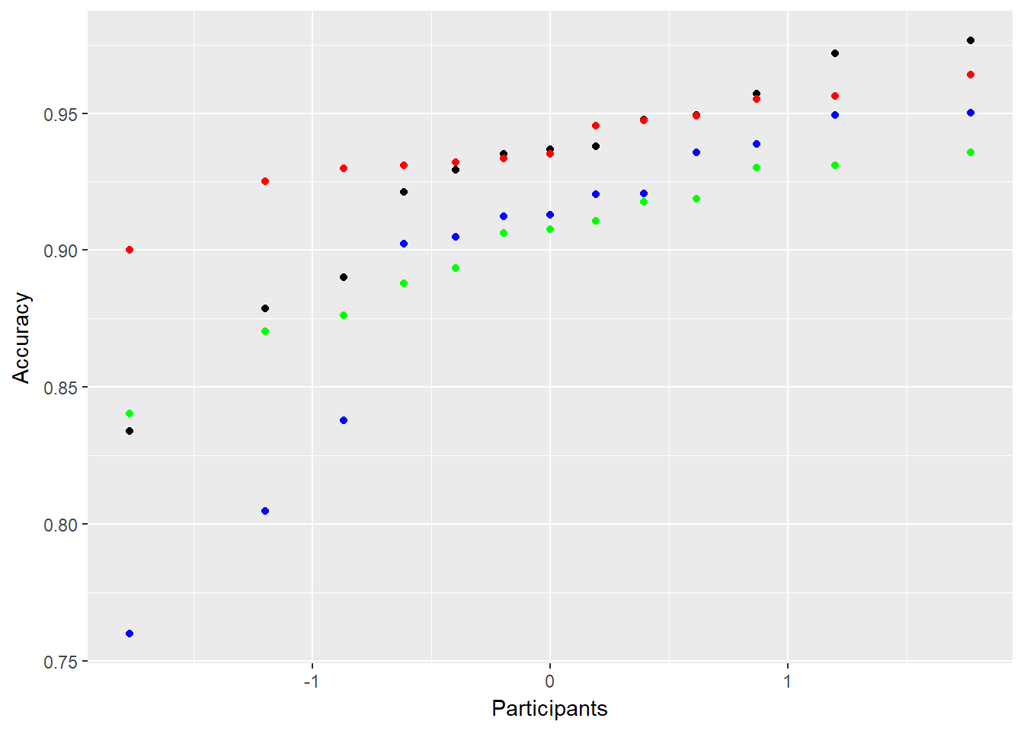

```r
ggplot(for_analysis)+
  geom_qq(mapping = aes(sample = sham_acc_h), color = "black")+
  geom_qq(mapping = aes(sample = sham_acc_l), color = "blue")+
  geom_qq(mapping = aes(sample = tacs_acc_h), color = "red")+
  geom_qq(mapping = aes(sample = tacs_acc_l), color = "green")+
  labs(y = "Accuracy" , x = "Participants")
```

there are some participants who has lower accuracy, good to know, but sofar they remain in the sample, they have also quality data

PLOTS that ressembles research questions

```r
library(wesanderson)
```

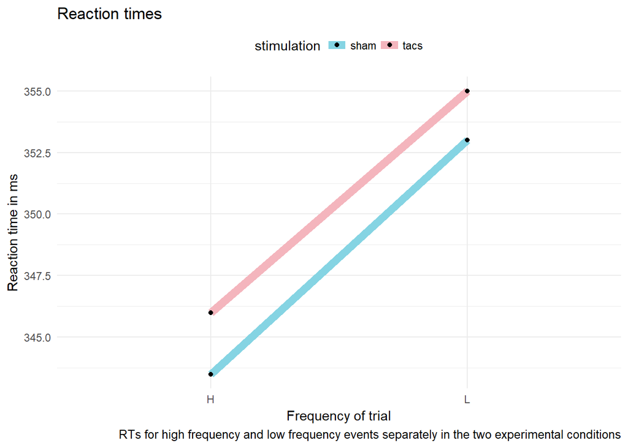

```r
plot_rt <- data_stim_raw %>%
  filter(triplet_type == "H" | triplet_type == "L") %>%
  filter(first_acc == 1) %>%
  group_by(stimulation, triplet_type) %>%
  summarise(median_rt = median(first_rt))

ggplot(plot_rt) +
  geom_line(aes(x = triplet_type, y = median_rt, group = stimulation, color = stimulation), size = 3) +
  scale_color_manual(values=wes_palette(n=2, name="Moonrise3"))+
  geom_point(aes(x = triplet_type, y = median_rt, group = stimulation, fill = stimulation))+
  scale_fill_manual(values=wes_palette(n=2, name="Moonrise3"))+
  theme_minimal()+
  labs(caption = "RTs for high frequency and low frequency events separately in the two experimental conditions")+
  labs(title = "Reaction times")+
  labs(x = "Frequency of trial" , y ="Reaction time in ms")+
  theme(legend.position = "top")
```

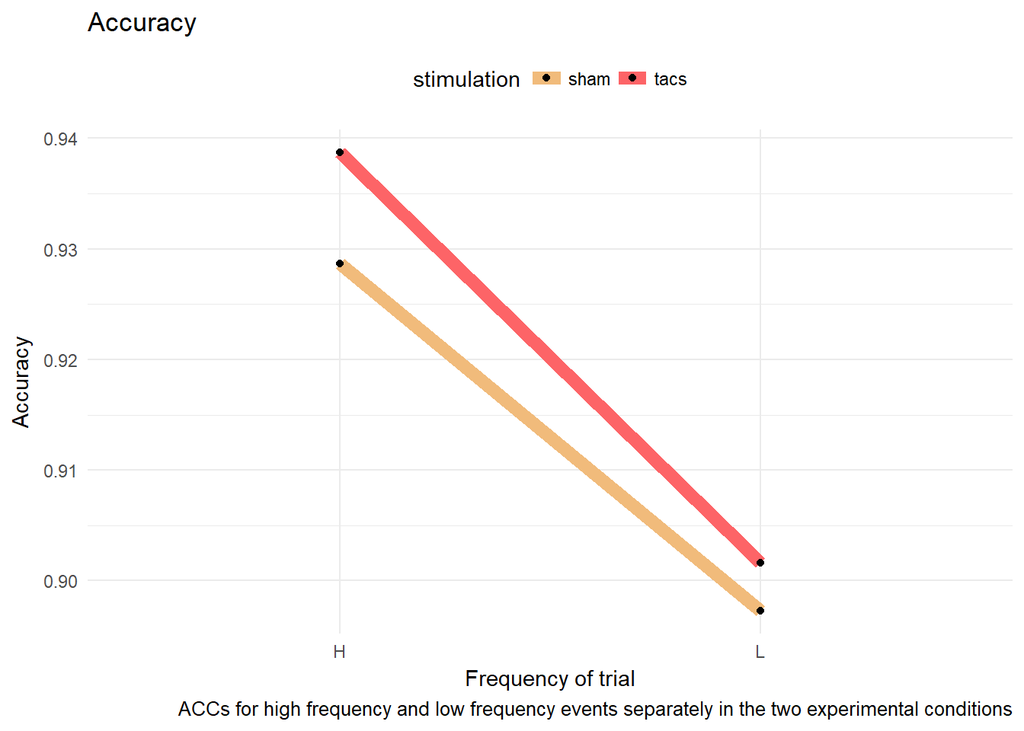

```r
ggsave("rt_plot.jpg", width = 10, height = 7)

plot_acc <- data_stim_raw %>%
  filter(triplet_type == "H" | triplet_type == "L") %>%
  group_by(stimulation, triplet_type) %>%
  summarise(mean_acc = mean(first_acc))

ggplot(plot_acc) +
  geom_line(aes(x = triplet_type, y = mean_acc, group = stimulation, color = stimulation), size = 3) +
  scale_color_manual(values=wes_palette(n=2, name="GrandBudapest"))+
  geom_point(aes(x = triplet_type, y = mean_acc, group = stimulation, fill = stimulation))+
  scale_fill_manual(values=wes_palette(n=2, name="GrandBudapest"))+
  theme_minimal()+
  labs(caption = "ACCs for high frequency and low frequency events separately in the two experimental conditions")+
  labs(title = "Accuracy")+
  labs(x = "Frequency of trial" , y ="Accuracy")+
  theme(legend.position = "top")
```

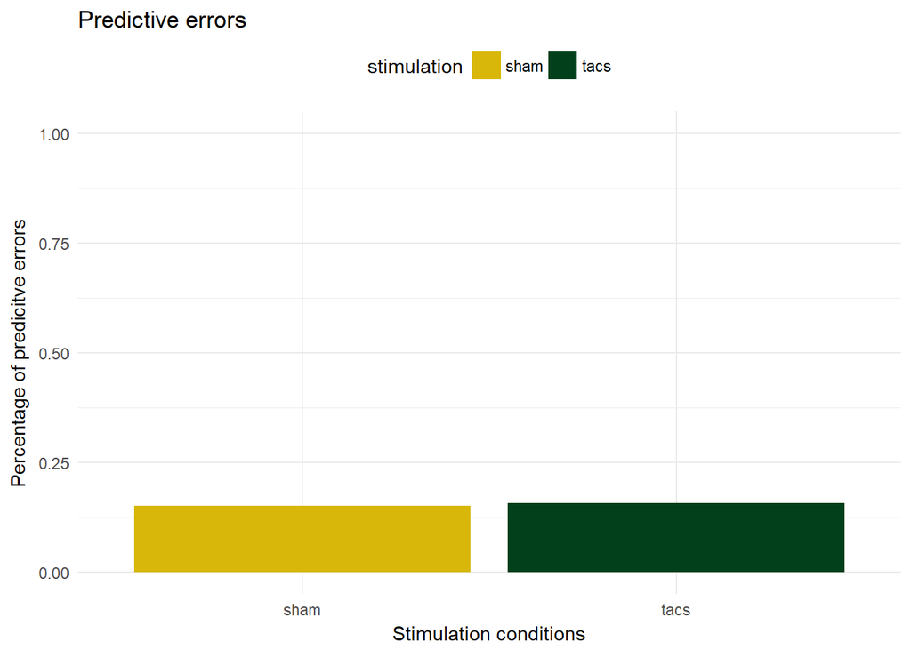

```r
ggsave("acc_plot.jpg", width = 10, height = 7)

plot_pred_error <- data_stim_raw %>%
  filter(triplet_type == "H" | triplet_type == "L") %>%
  filter(first_acc == 0) %>%
  group_by(stimulation) %>%
  summarise(avg_pred_e = mean(pred_error))

ggplot(data = plot_pred_error)+
  geom_col(aes(x = stimulation, y = avg_pred_e , fill = stimulation), position = "dodge")+
  scale_fill_manual(values=wes_palette(n=2, name="Cavalcanti"))+
  scale_y_continuous(limits = c(0, 1))+
  theme_minimal()+
  labs(x = "Stimulation conditions" , y = "Percentage of predicitve errors")+
  labs(title = "Predictive errors")+
  theme(legend.position = "top")
```

```r
ggsave("pred_error_plot.jpg", width = 10, height = 7)

rm(plot_rt, plot_acc, plot_pred_error)
```

assumption checking: normality (for the paired sample t-test)

```r
library(stats)

shapiro.test(for_analysis$sham_pred_e)
```

```
##
##  Shapiro-Wilk normality test
##
## data:  for_analysis$sham_pred_e
## W = 0.9218, p-value = 0.2652
```

```r
shapiro.test(for_analysis$tacs_pred_e)
```

```
##
##  Shapiro-Wilk normality test
##
## data:  for_analysis$tacs_pred_e
## W = 0.93882, p-value = 0.4418
```

```r
shapiro.test(for_analysis$sham_acc_ls)
```

```
##
##  Shapiro-Wilk normality test
##
## data:  for_analysis$sham_acc_ls
## W = 0.89221, p-value = 0.1046
```

```r
shapiro.test(for_analysis$tacs_acc_ls)
```

```
##
##  Shapiro-Wilk normality test
##
## data:  for_analysis$tacs_acc_ls
## W = 0.90552, p-value = 0.1592
```

```r
shapiro.test(for_analysis$sham_rt_ls)
```

```
##
##  Shapiro-Wilk normality test
##
## data:  for_analysis$sham_rt_ls
## W = 0.90638, p-value = 0.1636
```

```r
shapiro.test(for_analysis$tacs_rt_ls)
```

```
##
##  Shapiro-Wilk normality test
##
## data:  for_analysis$tacs_rt_ls
## W = 0.92684, p-value = 0.3097
```

```r
mean(for_analysis$tacs_rt_ls)
```

```
## [1] 11.42308
```

```r
max(for_analysis$tacs_rt_ls)
```

```
## [1] 24
```

```r
min(for_analysis$tacs_rt_ls)
```

```
## [1] 5
```

```r
sd(for_analysis$tacs_rt_ls)
```

```
## [1] 5.5522
```

```r
mean(for_analysis$sham_rt_ls)
```

```
## [1] 9.230769
```

```r
max(for_analysis$sham_rt_ls)
```

```
## [1] 21
```

```r
min(for_analysis$sham_rt_ls)
```

```
## [1] 1
```

```r
sd(for_analysis$sham_rt_ls)
```

```
## [1] 6.939066
```

```r
mean(for_analysis$tacs_acc_ls)
```

```
## [1] 0.03679646
```

```r
max(for_analysis$tacs_acc_ls)
```

```
## [1] 0.06177841
```

```r
min(for_analysis$tacs_acc_ls)
```

```
## [1] -0.005867468
```

```r
sd(for_analysis$tacs_acc_ls)
```

```
## [1] 0.02192221
```

```r
mean(for_analysis$sham_acc_ls)
```

```
## [1] 0.03201413
```

```r
max(for_analysis$sham_acc_ls)
```

```
## [1] 0.08540358
```

```r
min(for_analysis$sham_acc_ls)
```

```
## [1] 0.002321188
```

```r
sd(for_analysis$sham_acc_ls)
```

```
## [1] 0.02463467
```

```r
mean(for_analysis$tacs_pred_e)
```

```
## [1] 0.1734365
```

```r
max(for_analysis$tacs_pred_e)
```

```
## [1] 0.3
```

```r
min(for_analysis$tacs_pred_e)
```

```
## [1] 0.06666667
```

```r
sd(for_analysis$tacs_pred_e)
```

```
## [1] 0.0705575
```

```r
mean(for_analysis$sham_pred_e)
```

```
## [1] 0.1875947
```

```r
max(for_analysis$sham_pred_e)
```

```
## [1] 0.4444444
```

```r
min(for_analysis$sham_pred_e)
```

```
## [1] 0.0462963
```

```r
sd(for_analysis$sham_pred_e)
```

```
## [1] 0.1178097
```

testing Hypothesis 1: theta band tACS disrupts learning which results in less predictive errors

```r
t.test(x = for_analysis$sham_pred_e, y = for_analysis$tacs_pred_e,
         alternative = c("two.sided"),
         mu = 0, paired = TRUE, var.equal = TRUE,
         conf.level = 0.95)
```

```
##
##  Paired t-test
##
## data:  for_analysis$sham_pred_e and for_analysis$tacs_pred_e
## t = 0.37375, df = 12, p-value = 0.7151
## alternative hypothesis: true difference in means is not equal to 0
## 95 percent confidence interval:
##  -0.06837877  0.09669529
## sample estimates:
## mean of the differences
##              0.01415826
```

Hypothesis 1 is not supported by the data, thus it is rejected.

testing Hypothesis 2: theta band tacs disrupts learning which results in smaller learning scores

```r
t.test(x = for_analysis$sham_rt_ls, y = for_analysis$tacs_rt_ls,
       alternative = c("two.sided"),
       mu = 0, paired = TRUE, var.equal = TRUE,
       conf.level = 0.95)
```

```
##
##  Paired t-test
##
## data:  for_analysis$sham_rt_ls and for_analysis$tacs_rt_ls
## t = -1.8005, df = 12, p-value = 0.09694
## alternative hypothesis: true difference in means is not equal to 0
## 95 percent confidence interval:
##  -4.8451813  0.4605659
## sample estimates:
## mean of the differences
##               -2.192308
```

```r
t.test(x = for_analysis$sham_acc_ls, y = for_analysis$tacs_acc_ls,
       alternative = c("two.sided"),
       mu = 0, paired = TRUE, var.equal = TRUE,
       conf.level = 0.95)
```

```
##
##  Paired t-test
##
## data:  for_analysis$sham_acc_ls and for_analysis$tacs_acc_ls
## t = -0.57295, df = 12, p-value = 0.5773
## alternative hypothesis: true difference in means is not equal to 0
## 95 percent confidence interval:
##  -0.02296867  0.01340401
## sample estimates:
## mean of the differences
##            -0.004782331
```

Hypothesis 2 is not supported by the data, thus it is rejected.

testing Hypothesis 3: stimulation per se does not affect average performance

```r
t.test(x = for_analysis$sham_avg_rt, y = for_analysis$tacs_avg_rt,
       alternative = c("two.sided"),
       mu = 0, paired = TRUE, var.equal = TRUE,
       conf.level = 0.95)
```

```
##
##  Paired t-test
##
## data:  for_analysis$sham_avg_rt and for_analysis$tacs_avg_rt
## t = -0.37119, df = 12, p-value = 0.717
## alternative hypothesis: true difference in means is not equal to 0
## 95 percent confidence interval:
##  -33.10045  23.46388
## sample estimates:
## mean of the differences
##               -4.818285
```

```r
t.test(x = for_analysis$sham_avg_acc, y = for_analysis$tacs_avg_acc,
       alternative = c("two.sided"),
       mu = 0, paired = TRUE, var.equal = TRUE,
       conf.level = 0.95)
```

```
##
##  Paired t-test
##
## data:  for_analysis$sham_avg_acc and for_analysis$tacs_avg_acc
## t = -0.4228, df = 12, p-value = 0.6799
## alternative hypothesis: true difference in means is not equal to 0
## 95 percent confidence interval:
##  -35.07453  23.67432
## sample estimates:
## mean of the differences
##               -5.700101
```

Finally check whether N of predictive errors and learning scores are correleted in the two experimental conditions.

```r
cor.test(for_analysis$sham_pred_e, for_analysis$sham_rt_ls, method = "spearman")
```

```
##
##  Spearman's rank correlation rho
##
## data:  for_analysis$sham_pred_e and for_analysis$sham_rt_ls
## S = 254.7, p-value = 0.3188
## alternative hypothesis: true rho is not equal to 0
## sample estimates:
##       rho
## 0.3002766
```

```r
cor.test(for_analysis$tacs_pred_e, for_analysis$tacs_rt_ls, method = "spearman")
```

```
##
##  Spearman's rank correlation rho
##
## data:  for_analysis$tacs_pred_e and for_analysis$tacs_rt_ls
## S = 421.16, p-value = 0.6084
## alternative hypothesis: true rho is not equal to 0
## sample estimates:
##        rho
## -0.1570254
```

```r
cor.test(for_analysis$sham_pred_e, for_analysis$sham_acc_ls, method = "spearman")
```

```
##
##  Spearman's rank correlation rho
##
## data:  for_analysis$sham_pred_e and for_analysis$sham_acc_ls
## S = 228, p-value = 0.2094
## alternative hypothesis: true rho is not equal to 0
## sample estimates:
##       rho
## 0.3736264
```

```r
cor.test(for_analysis$tacs_pred_e, for_analysis$tacs_acc_ls, method = "spearman")
```

```
##
##  Spearman's rank correlation rho
##
## data:  for_analysis$tacs_pred_e and for_analysis$tacs_acc_ls
## S = 446, p-value = 0.459
## alternative hypothesis: true rho is not equal to 0
## sample estimates:
##        rho
## -0.2252747
```

None of the correlates are significant.

End of the analysis and the code.